# si670-hw3-yuacheng

## SI 670 Applied Machine Learning, Week 3: Regularization, Logistic Regression, and Evaluation (Due 09/28 11:59pm)

For this assignment, you will be exercising on questions related to linear regression, polynomial feature expansion, underfitting/overfitting, and cross-validation.

Each question is worth 20 points, for a total of 100 points. Correct answers and code receive full credit, but partial credit will be awarded if you have the right idea even if your final answers aren't quite right.

Submit your completed notebook file to the Canvas site - IMPORTANT: please name your submitted file si670-hw1-youruniqname.ipynb and be sure to put your name at the top of your notebook file. Please also make sure to upload the html version.

As a reminder, the notebook code you submit must be your own work. Feel free to discuss general approaches to the homework with classmates: if you end up forming more of a team discussion on multiple questions, please include the names of the people you worked with at the top of your notebook file.

### Put your name here:

### Put your uniquename here:

### Preliminary

In this assignment you will train several linear classifier models and evaluate how effectively they predict instances of fraud using data based on the Kaggle dataset (uploaded on Canvas). Then you'll perform a grid search to find optimal parameters.

Each row in `fraud_data.csv` corresponds to a credit card transaction. Features include confidential variables `V1` through `V28` as well as `Amount` which is the amount of the transaction.

The target is stored in the `class` column, where a value of 1 corresponds to an instance of fraud and 0 corresponds to an instance of not fraud.

```python
# # run this cell if you are using Colab

# !rm -rf fraud_data.csv

# import io

# from google.colab import files as colab_files
# uploaded = colab_files.upload()
# files = {'fraud_data.csv': io.BytesIO(uploaded['fraud_data.csv'])}

# # upload 'fraud_data.csv'
```

```python
# run this cell if you are using Jupyter
files = {'fraud_data.csv': 'fraud_data.csv'}
```

```python
%matplotlib inline
import matplotlib.pyplot as plt
import numpy as np
import pandas as pd
from sklearn.model_selection import train_test_split
from sklearn.metrics import accuracy_score, precision_score, recall_score, f1_score
from sklearn.dummy import DummyClassifier
from sklearn.model_selection import train_test_split
from sklearn.linear_model import LogisticRegression
from sklearn.metrics import precision_recall_curve
from sklearn.metrics import roc_curve, auc
import warnings

df = pd.read_csv(files['fraud_data.csv'])

X = df.iloc[:,:-1]
y = df.iloc[:,-1]

X_train, X_test, y_train, y_test = train_test_split(X, y, random_state=0)
```

### Question 1 (20 points)

Using `X_train`, `X_test`, `y_train`, and `y_test` (as defined above), train a dummy classifier that classifies everything as the majority class of the training data. What is the accuracy of this classifier? What is the recall?

Then train a LogisticRegression classifier with C=1. What is the accuracy? What is the recall?

*This function should a return a tuple with four floats, i.e. `(dummy_accuracy, dummy_recall, lr_accuracy, lr_recall)`.*

```python
df.head()
```

|  | V1 | V2 | V3 | V4 | V5 | V6 | V7 | V8 | V9 | V10 | ... | V21 | V22 | V23 | V24 | V25 | V26 | V27 | V28 | Amount | Class |
| --- | --- | --- | --- | --- | --- | --- | --- | --- | --- | --- | --- | --- | --- | --- | --- | --- | --- | --- | --- | --- | --- |
| 0 | 1.176563 | 0.323798 | 0.536927 | 1.047002 | -0.368652 | -0.728586 | 0.084678 | -0.069246 | -0.266389 | 0.155315 | ... | -0.109627 | -0.341365 | 0.057845 | 0.499180 | 0.415211 | -0.581949 | 0.015472 | 0.018065 | 4.67 | 0 |
| 1 | 0.681109 | -3.934776 | -3.801827 | -1.147468 | -0.735540 | -0.501097 | 1.038865 | -0.626979 | -2.274423 | 1.527782 | ... | 0.652202 | 0.272684 | -0.982151 | 0.165900 | 0.360251 | 0.195321 | -0.256273 | 0.056501 | 912.00 | 0 |
| 2 | 1.140729 | 0.453484 | 0.247010 | 2.383132 | 0.343287 | 0.432804 | 0.093380 | 0.173310 | -0.808999 | 0.775436 | ... | -0.003802 | 0.058556 | -0.121177 | -0.304215 | 0.645893 | 0.122600 | -0.012115 | -0.005945 | 1.00 | 0 |
| 3 | -1.107073 | -3.298902 | -0.184092 | -1.795744 | 2.137564 | -1.684992 | -2.015606 | -0.007181 | -0.165760 | 0.869659 | ... | 0.130648 | 0.329445 | 0.927656 | -0.049560 | -1.892866 | -0.575431 | 0.266573 | 0.414184 | 62.10 | 0 |
| 4 | -0.314818 | 0.866839 | -0.124577 | -0.627638 | 2.651762 | 3.428128 | 0.194637 | 0.670674 | -0.442658 | 0.133499 | ... | -0.312774 | -0.799494 | -0.064488 | 0.953062 | -0.429550 | 0.158225 | 0.076943 | -0.015051 | 2.67 | 0 |

5 rows × 30 columns

```python
def answer_one():
    dummy_majority = DummyClassifier(strategy='most_frequent').fit(X_train, y_train)
    y_dummy_predictions = dummy_majority.predict(X_test)
    dummy_accuracy = dummy_majority.score(X_test, y_test)
    dummy_recall = recall_score(y_test, y_dummy_predictions)

    clf = LogisticRegression().fit(X_train, y_train)
    lr_predictions = clf.predict(X_test)
    lr_accuracy = clf.score(X_test, y_test)
    lr_recall = recall_score(y_test, lr_predictions)
    return (dummy_accuracy, dummy_recall, lr_accuracy, lr_recall)
dummy_accuracy, dummy_recall, lr_accuracy, lr_recall = answer_one()
print(dummy_accuracy, dummy_recall, lr_accuracy, lr_recall)
# answer_one()
```

```
0.9852507374631269 0.0 0.9963126843657817 0.7875
```

### Question 2 (20 points)

*This function should a return a tuple with four lists, i.e. `(accuracy_list, precision_list, recall_list, f1_list)`, and each list should contain 3 numbers.*

```python
def answer_two():
    accuracy_list=[]
    precision_list=[]
    recall_list=[]
    f1_list=[]
    # YOUR CODE HERE
    for this_C in [0.01,1, 100]:
        clf = LogisticRegression(C=this_C).fit(X_train, y_train)
        lr_predictions = clf.predict(X_test)
        lr_accuracy = clf.score(X_test, y_test)
        lr_precision = precision_score(y_true=y_test,y_pred=lr_predictions)
        lr_recall = recall_score(y_true=y_test, y_pred=lr_predictions)
        lr_f1 = f1_score(y_true=y_test, y_pred=lr_predictions)
        accuracy_list.append(lr_accuracy)
        precision_list.append(lr_precision)
        recall_list.append(lr_recall)
        f1_list.append(lr_f1)

    return (accuracy_list, precision_list, recall_list, f1_list)

accuracy_list, precision_list, recall_list, f1_list = answer_two()
print(accuracy_list, precision_list, recall_list, f1_list)
# answer_two()
```

```
[0.9964970501474927, 0.9963126843657817, 0.9964970501474927] [0.9692307692307692, 0.9545454545454546, 0.9692307692307692] [0.7875, 0.7875, 0.7875] [0.8689655172413793, 0.8630136986301369, 0.8689655172413793]
```

### Question 3 (20 points)

Train a logistic regression classifier with `C=10` using X_train and y_train.

For the logistic regression classifier, create (1) a precision-recall curve and (2) a roc curve using y_test and the probability estimates for X_test (probability it is fraud).

Looking at the precision recall curve, what is the recall when the precision is `0.75`?

Looking at the ROC curve, what is the true positive rate when the false positive rate is `0.16`?

*This function should return a tuple with two floats, i.e. `(recall_at_p75, tpr_at_fpr16)`.* *You should also includce code to generate the precision/recall and ROC curves above*

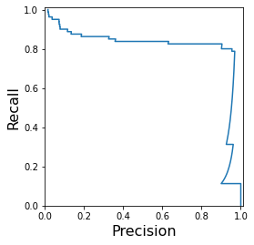

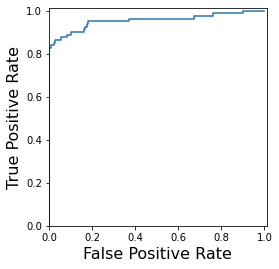

```
0.825 0.9125
```

```python
def answer_three():
    # YOUR CODE HERE
    lr = LogisticRegression(C=10)
    y_score_lr = lr.fit(X_train, y_train).decision_function(X_test)
    y_score_list = list(y_score_lr)
    precision, recall, thresholds = precision_recall_curve(y_test, y_score_lr)

    recall_at_p75 = np.interp(0.75, precision, recall)

    fpr, tpr, _ = roc_curve(y_test, y_score_lr)
    tpr_at_fpr16 = np.interp(0.16, fpr, tpr)

    plt.figure()
    plt.xlim([0.0, 1.01])
    plt.ylim([0.0, 1.01])
    plt.plot(precision, recall, label='Precision-Recall Curve')
    plt.xlabel('Precision', fontsize=16)
    plt.ylabel('Recall', fontsize=16)
    plt.axes().set_aspect('equal')
    plt.show()

    plt.figure()
    plt.xlim([0.0, 1.01])
    plt.ylim([0.0, 1.01])
    plt.plot(fpr, tpr, label='ROC Curve')
    plt.xlabel('False Positive Rate', fontsize=16)
    plt.ylabel('True Positive Rate', fontsize=16)
    plt.axes().set_aspect('equal')
    plt.show()

    return (recall_at_p75, tpr_at_fpr16)
recall_at_p75, tpr_at_fpr16 = answer_three()
print(recall_at_p75, tpr_at_fpr16)

# answer_three()
```

## Question 4 (20 Points)

Suppose you have trained a classifier distinguishing Benign vs Malignant cancers. And the confusion matrix of your classifier is given below.

|  | Predicted: Benign | Predicted: Malignant |
| --- | --- | --- |
| Actual: Benign | 10000 | 100 |
| Actual: Malignant | 200 | 10 |

### Question (a) (10 points)

If we assume Benign is the positive class and Malignant is the negative class, what are the precision and recall for Benign? If we assume Malignant is the positive class and Benign is the negative class, what are the precision and recall for Malignant?

*This function should return a tuple of four float numbers: `(precision_benign, recall_genign, precision_maligant, recall_maligant)`. You can calculate these scores either by coding or by hands.*

```python
def answer_four_a():
    # Coding or manually calculating the precision and recall scores here.

    precision_benign = 10000/(10000+100)
    recall_benign = 10000/(10000+200)
    precision_malignant = 10/(10+200)
    recall_malignant = 10/(10+100)
    return precision_benign, recall_benign, precision_malignant, recall_malignant
precision_benign, recall_benign, precision_malignant, recall_malignant = answer_four_a()
print(precision_benign, recall_benign, precision_malignant, recall_malignant)
# answer_four_a()
```

```
0.9900990099009901 0.9803921568627451 0.047619047619047616 0.09090909090909091
```

### Question (b) (10 points)

If you have another classifier with the following confusion matrix, which classifier do you prefer and why? (Hint: calculate the precision and recall scores for this classifier and compare with the previous classifier.)

|  | Predicted: Benign | Predicted: Malignant |
| --- | --- | --- |
| Actual: Benign | 7000 | 3100 |
| Actual: Malignant | 30 | 180 |

## Question 5 (20 Points)

Now, we will compare the performance of Ridge, Lasso and OLS perform on the dataset where the relationship between X and y is non-linear.

Let's start by generating some data using the function below.

```python
import numpy as np

def generate_data(n_samples, n_features, noise=0.0, random_state=670):
    assert n_features > 1
    rs = np.random.RandomState(random_state)
    X = rs.uniform(size=(n_samples, n_features))
    y = 3 * np.sin(2*np.pi * X[:, 0]) + 6.7 * X[:, 1] + 10 * np.power(X[:, 2], 3) + noise * rs.normal(size=(n_samples,))
    return X, y
X, y = generate_data(n_samples = 200, n_features=10, noise=1, random_state=670)
```

### Question 5 (a) Feature expansion (5 points)

First, we are going use sklearn.preprocessing.PolynomialFeatures with `degree = 3` to expand the feature (Remeber we did that in Lab 2!)

*This function should return `X_poly`, which is the new feature set after feature expansion.*

```python
from sklearn.preprocessing import PolynomialFeatures
def answer_five_expansion():
    poly = PolynomialFeatures(degree=3)
    X_poly = poly.fit_transform(X)
    return X_poly
X_poly = answer_five_expansion()
print(X_poly)
```

```
[[1.00000000e+00 5.68227393e-02 2.27414107e-02 ... 2.35360618e-02
  4.68318550e-02 9.31856257e-02]
 [1.00000000e+00 9.05263188e-01 9.24187355e-01 ... 4.14924001e-01
  2.41676170e-01 1.40766431e-01]
 [1.00000000e+00 6.50709351e-01 1.28597300e-01 ... 1.59759055e-02
  2.22254166e-02 3.09196333e-02]
 ...
 [1.00000000e+00 8.93692785e-01 4.15921030e-01 ... 3.76747976e-02
  6.24732846e-02 1.03594751e-01]
 [1.00000000e+00 3.99743480e-01 8.59403360e-01 ... 2.18379718e-03
  1.79022498e-03 1.46758385e-03]
 [1.00000000e+00 2.03035027e-01 1.87128496e-01 ... 1.68814391e-04
  1.09333436e-03 7.08103150e-03]]
```

### Question 5 (b) Split and Standardize (5 points)

Then, split the training and testing data with `train_size = 0.8` and `random_state = 670`, and use the `sklearn.preprocessing.StandardScaler` to normalize the feature `X_poly` and .

*This function should return the standardized dataset, `standardized_X_poly_train, standardized_X_poly_test, y_poly_train, y_poly_test`.*

```python
from sklearn.model_selection import train_test_split
from sklearn.preprocessing import StandardScaler

def answer_five_split_standardize():
    X_poly = answer_five_expansion()
    X_poly_train, X_poly_test, y_poly_train, y_poly_test = train_test_split(X_poly, y, random_state=670, train_size=0.8)
    scaler = StandardScaler()

    standardized_X_poly_train = scaler.fit_transform(X_poly_train)
    standardized_X_poly_test = scaler.transform(X_poly_test)


    return standardized_X_poly_train, standardized_X_poly_test, y_poly_train, y_poly_test
standardized_X_poly_train, standardized_X_poly_test, y_poly_train, y_poly_test = answer_five_split_standardize()
print(standardized_X_poly_train, standardized_X_poly_test, y_poly_train, y_poly_test)
```

[output not shown]

### Question 5 (c-1) Model comparison (2 points)

If we train different linear models, i.e., Linear Regression, Ridge, and Lasso, with the pre-processed training set (standardized_X_poly_train, y_poly_train), which model do you expect to generate the best performance on the testing set and why?

#### Answer to Question 5 (c-1)

Write your answer here.

I would expect the Lasson regression would generate the best performance on the testing set because both linear regression and ridge regression cannot let the some unimportant features become 0 so that the result coulbe be overfitting.

### Question 5 (c-2) Model comparison and model selection (8 points)

Next, let's see which model indeed performs better on our dataset. In this function, you will:

- Train a Linear Regression model (with default settings), and print the training and testing R-squared scores;
- Train a Ridge model for each alpha in the `alpha_list`, select the Ridge model that generates the highest R-squared score on the training set, print both the training and testing R-squared scores of the best-performing Ridge model (i.e., the model with the alpha that generates the highest R-squared score);
- Train a Lasso model for each alpha in the `alpha_list`, select the Lasso model that generates the highest R-squared score on the training set, print both the training and testing R-squared scores of the best-performing Lasso model (i.e., the Lasso model with the alpha that generates the highest R-squared score);
- Return the the training and testing R-squared scores of the Linear Regression model, the best-performing Ridge model, and the best-performing Lasso model: `linreg_r_2_train, linreg_r_2_test, best_ridgereg_r_2_train, best_ridgereg_r_2_test, best_lassoreg_r_2_train, best_lassoreg_r_2_test)`.

```python
from sklearn.linear_model import Lasso, Ridge, LinearRegression

def answer_five_compare():

    standardized_X_poly_train, standardized_X_poly_test, y_poly_train, y_poly_test = answer_five_split_standardize()

    alpha_list = [0.01, 0.1, 1, 2, 3, 5, 10, 50, 100, 200]

    # -------------------- Linear Regression ----------------
    # Your code

    linreg = LinearRegression().fit(standardized_X_poly_train,y_poly_train)
    linreg_r_2_train = linreg.score(standardized_X_poly_train,y_poly_train)
    linreg_r_2_test= linreg.score(standardized_X_poly_test, y_poly_test)
    print('R-squared score of Linear Regression (train): {:.3f}'.format(linreg_r_2_train))
    print('R-squared score of Linear Regression (test): {:.3f}'.format(linreg_r_2_test))

    # -------------------- Ridge ---------------------------

    # Your code
    ridgereg_r_2_train = []
    ridgereg_r_2_test = []
    for this_alpha in alpha_list:
        model = Ridge(alpha= this_alpha).fit(standardized_X_poly_train,y_poly_train)
        ridgereg_r_2_train.append(model.score(standardized_X_poly_train,y_poly_train))
        ridgereg_r_2_test.append(model.score(standardized_X_poly_test, y_poly_test))
    best_ridgereg_r_2_train = max(ridgereg_r_2_train)
    best_ridgereg_r_2_test = max(ridgereg_r_2_test)

    print('R-squared score of Ridge Regression (train): {:.3f}'.format(best_ridgereg_r_2_train))
    print('R-squared score of Ridge Regression (test): {:.3f}'.format(best_ridgereg_r_2_test))

    # -------------------- Lasso ---------------------------

    # Your code
    lassoreg_r_2_train=[]
    lassoreg_r_2_test=[]
    for alpha in alpha_list:
        model=Lasso(alpha=alpha).fit(standardized_X_poly_train, y_poly_train)
        lassoreg_r_2_test.append(model.score(standardized_X_poly_test,y_poly_test))
        lassoreg_r_2_train.append(model.score(standardized_X_poly_train, y_poly_train))

    best_lassoreg_r_2_train = max(lassoreg_r_2_train)
    best_lassoreg_r_2_test = max(lassoreg_r_2_test)
    print('R-squared score of Lasso Regression (train): {:.3f}'.format(best_lassoreg_r_2_train))
    print('R-squared score of Lasso Regression (test): {:.3f}'.format(best_lassoreg_r_2_test))

    return (linreg_r_2_train, linreg_r_2_test, best_ridgereg_r_2_train, best_ridgereg_r_2_test,
            best_lassoreg_r_2_train, best_lassoreg_r_2_test)

linreg_r_2_train, linreg_r_2_test, best_ridgereg_r_2_train, best_ridgereg_r_2_test,best_lassoreg_r_2_train, best_lassoreg_r_2_test = answer_five_compare()
print(linreg_r_2_train, linreg_r_2_test, best_ridgereg_r_2_train, best_ridgereg_r_2_test,best_lassoreg_r_2_train, best_lassoreg_r_2_test)
```

```
R-squared score of Linear Regression (train): 1.000
R-squared score of Linear Regression (test): 0.274
R-squared score of Ridge Regression (train): 1.000
R-squared score of Ridge Regression (test): 0.782
R-squared score of Lasso Regression (train): 0.961
R-squared score of Lasso Regression (test): 0.779
1.0 0.27414945807504343 0.9999539315772665 0.7815430781307768 0.9612569688756332 0.778643962546157
```